# Data Understanding and Preparation

```python
# current size of the dataframe
print("current size of the dataframe:",games_df.shape)
```

```
current size of the dataframe: (53392, 20)
```

```python
# reset index of games_df
games_df.reset_index(drop=True,inplace=True)
```

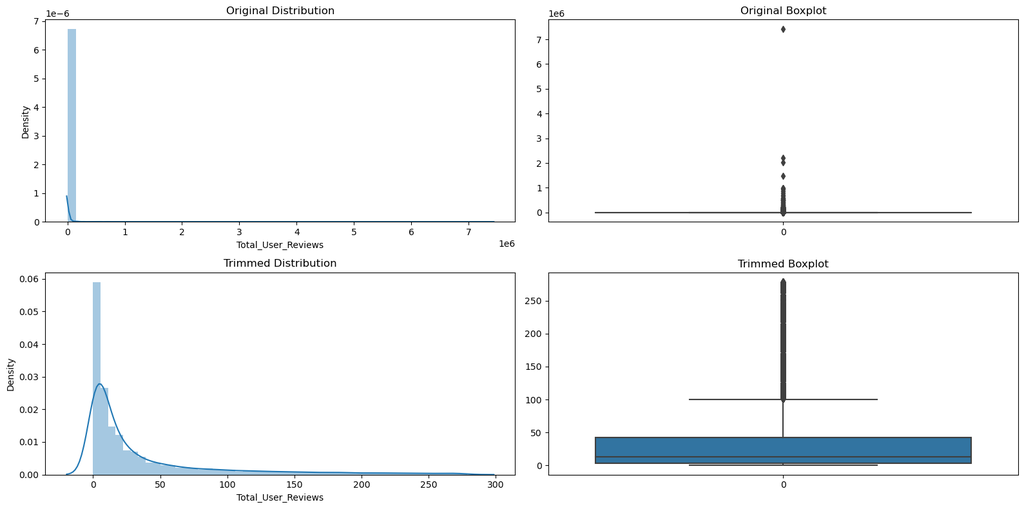

```
Original Dataset Statistics:
Previous dataset size: 53392
mean: 1590.59
max: 7428921.0
min: 0.0
std: 38589.05

Trimmed Dataset Statistics:
Current dataset size: 44516
mean: 36.90
max: 279.0
min: 0.0
std: 55.90

Number of outliers removed: 8876 (0.1662421336529817)
```

```python
warnings.filterwarnings('ignore')
# Since there's way too many outliers on the dependant variable (games with many reviews compared to the vast majority which have less reviews)
# we're going to use the Inter Quartile Range method for identifying these outliers and removing them

#  Finding the IQR
percentile25 = games_df['Total_User_Reviews'].quantile(0.25)
percentile75 = games_df['Total_User_Reviews'].quantile(0.75)
iqr = percentile75 - percentile25

# Finding the upper and lower limits
upper_limit = percentile75 + 1.5 * iqr
lower_limit = percentile25 - 1.5 * iqr

# Finding outliers
outliers_high = games_df[games_df['Total_User_Reviews'] > upper_limit]
outliers_low = games_df[games_df['Total_User_Reviews'] < lower_limit]

# Trimming outliers
trimmed_df = games_df[(games_df['Total_User_Reviews'] < upper_limit) & (games_df['Total_User_Reviews'] > lower_limit)]
trimmed_df.reset_index(drop=True,inplace=True)
# Compare the plots after trimming
plt.figure(figsize=(16, 8))

plt.subplot(2, 2, 1)
sns.distplot(games_df['Total_User_Reviews'])
plt.title('Original Distribution')

plt.subplot(2, 2, 2)
sns.boxplot(games_df['Total_User_Reviews'])
plt.title('Original Boxplot')

plt.subplot(2, 2, 3)
sns.distplot(trimmed_df['Total_User_Reviews'])
plt.title('Trimmed Distribution')

plt.subplot(2, 2, 4)
sns.boxplot(trimmed_df['Total_User_Reviews'])
plt.title('Trimmed Boxplot')

plt.tight_layout()
plt.show()

print("Original Dataset Statistics:")
print(f"Previous dataset size: {len(games_df)}")
print(f"mean: {games_df['Total_User_Reviews'].mean():.2f}")
print(f"max: {games_df['Total_User_Reviews'].max()}")
print(f"min: {games_df['Total_User_Reviews'].min()}")
print(f"std: {games_df['Total_User_Reviews'].std():.2f}")

print("\nTrimmed Dataset Statistics:")
print(f"Current dataset size: {len(trimmed_df)}")
print(f"mean: {trimmed_df['Total_User_Reviews'].mean():.2f}")
print(f"max: {trimmed_df['Total_User_Reviews'].max()}")
print(f"min: {trimmed_df['Total_User_Reviews'].min()}")
print(f"std: {trimmed_df['Total_User_Reviews'].std():.2f}")

# Number of outliers removed
num_outliers_removed = len(games_df) - len(trimmed_df)
print("\nNumber of outliers removed:", num_outliers_removed, f"({num_outliers_removed/len(games_df)})")
```

```python
# The dataset statistics have changed significantly, we can now assign the trimmed dataset to games_df
games_df = trimmed_df
```

```python
# Should we filter the dataset so it only includes games with the "Indie" tag?
mask_indie = games_df["Popular Tags"].str.contains("Indie")
indie_games_df = games_df[mask_indie]
print("only Indie tag dataframe size:",indie_games_df.shape)
print(games_df.shape[0]-indie_games_df.shape[0],"less games")
```

```
only Indie tag dataframe size: (29564, 20)
14952 less games
```

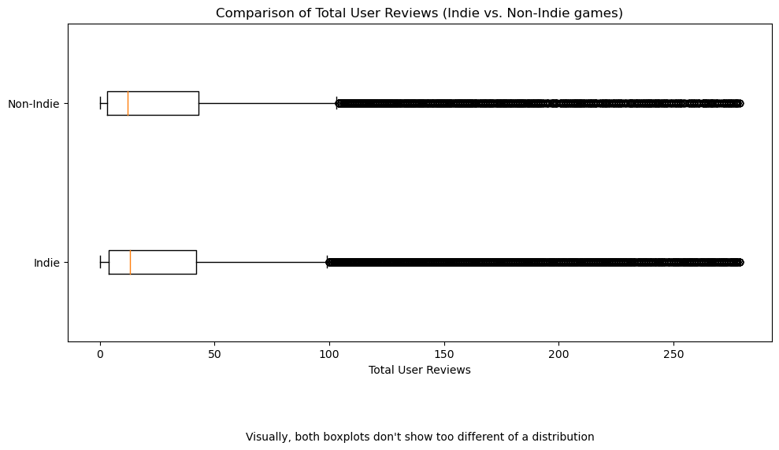

```
29564
14952
```

```python
# Mask definitions (assuming mask_indie is defined)
fig, ax = plt.subplots(figsize=(10, 6))  # Create a single subplot

# Boxplot for Indie games
ax.boxplot(games_df[mask_indie]["Total_User_Reviews"].dropna(), positions=[0], vert=False)
# Boxplot for Non-Indie games
ax.boxplot(games_df[~mask_indie]["Total_User_Reviews"].dropna(), positions=[1], vert=False)

ax.set_yticklabels(['Indie', 'Non-Indie'])  # Set y-axis labels
ax.set_xlabel('Total User Reviews')
ax.set_title('Comparison of Total User Reviews (Indie vs. Non-Indie games)')

# Add a note under the plot
plt.text(0.5, -0.3, "Visually, both boxplots don't show too different of a distribution",
         horizontalalignment='center', verticalalignment='center', transform=ax.transAxes)


plt.tight_layout()
plt.show()

# Output lengths
print(len(games_df[mask_indie]["Total_User_Reviews"].dropna()))
print(len(games_df[~mask_indie]["Total_User_Reviews"].dropna()))
```

It doesn't seem that indie games and non indie games (based on the tag) differ a lot in regards to the distribution of both. Hence, we choose not to create a separate category or remove non-indie games

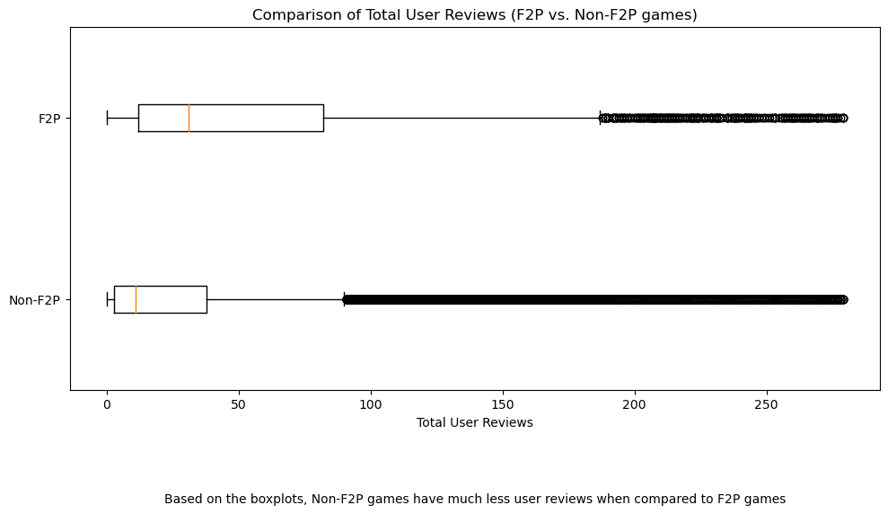

```python
# Check if we should do some kind of treatment for free to play games
f2p_mask = (games_df["Original Price"].str.contains("Free"))

fig, ax = plt.subplots(figsize=(10, 6))  # Create a single subplot

# Boxplot for Non-F2P games
ax.boxplot(games_df[~f2p_mask]["Total_User_Reviews"].dropna(), positions=[0], vert=False)
# Boxplot for F2P games
ax.boxplot(games_df[f2p_mask]["Total_User_Reviews"].dropna(), positions=[1], vert=False)

ax.set_yticklabels(['Non-F2P', 'F2P'])  # Set y-axis labels
ax.set_xlabel('Total User Reviews')
ax.set_title('Comparison of Total User Reviews (F2P vs. Non-F2P games)')

# Add a note under the plot
plt.text(0.5, -0.3, "Based on the boxplots, Non-F2P games have much less user reviews when compared to F2P games",
         horizontalalignment='center', verticalalignment='center', transform=ax.transAxes)

plt.tight_layout()
plt.show()
```

```python
# Because the distributions differ a lot foro F2P and non-FTP games, we'll create a new variable that differentiates them
games_df["F2P"] = games_df["Original Price"].str.contains("Free").astype(int)
```

## Price of games

Analyis and removal of outliers for price of games

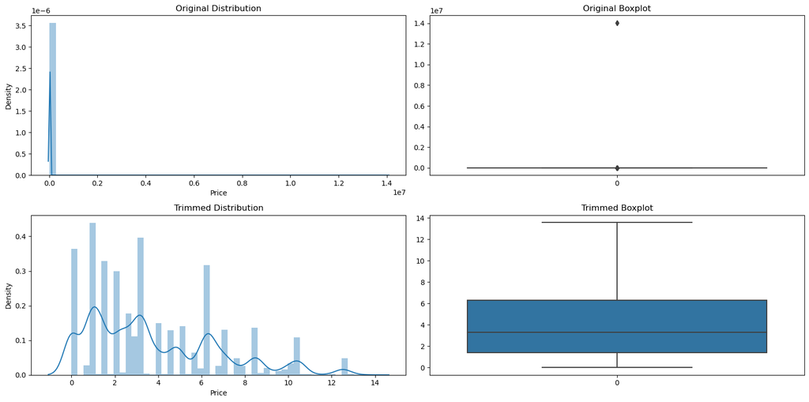

```
Original Dataset Statistics:
Previous dataset size: 44516
mean: 952.08
max: 14046333.0
min: 0.0
std: 115306.99

Trimmed Dataset Statistics:
Current dataset size: 43303
mean: 3.78
max: 13.57
min: 0.0
std: 3.02

Number of outliers removed: 1213 (0.02724862970617306)
```

```python
# IQR method will be used again to see what values can we keep
warnings.filterwarnings('ignore')
# Since there's way too many outliers on the dependant variable, we're going to use the Inter Quartile Range method
# For identifying and removing them

#  Finding the IQR
percentile25 = games_df['Price'].quantile(0.25)
percentile75 = games_df['Price'].quantile(0.75)
iqr = percentile75 - percentile25

# Finding the upper and lower limits
upper_limit = percentile75 + 1.5 * iqr
lower_limit = percentile25 - 1.5 * iqr

# Finding outliers
outliers_high = games_df[games_df['Price'] > upper_limit]
outliers_low = games_df[games_df['Price'] < lower_limit]

# Trimming outliers
trimmed_df = games_df[(games_df['Price'] < upper_limit) & (games_df['Price'] > lower_limit)]
trimmed_df.reset_index(drop=True,inplace=True)
# Compare the plots after trimming
plt.figure(figsize=(16, 8))

plt.subplot(2, 2, 1)
sns.distplot(games_df['Price'])
plt.title('Original Distribution')

plt.subplot(2, 2, 2)
sns.boxplot(games_df['Price'])
plt.title('Original Boxplot')

plt.subplot(2, 2, 3)
sns.distplot(trimmed_df['Price'])
plt.title('Trimmed Distribution')

plt.subplot(2, 2, 4)
sns.boxplot(trimmed_df['Price'])
plt.title('Trimmed Boxplot')

plt.tight_layout()
plt.show()

print("Original Dataset Statistics:")
print(f"Previous dataset size: {len(games_df)}")
print(f"mean: {games_df['Price'].mean():.2f}")
print(f"max: {games_df['Price'].max()}")
print(f"min: {games_df['Price'].min()}")
print(f"std: {games_df['Price'].std():.2f}")

print("\nTrimmed Dataset Statistics:")
print(f"Current dataset size: {len(trimmed_df)}")
print(f"mean: {trimmed_df['Price'].mean():.2f}")
print(f"max: {trimmed_df['Price'].max()}")
print(f"min: {trimmed_df['Price'].min()}")
print(f"std: {trimmed_df['Price'].std():.2f}")

# Number of outliers removed
num_outliers_removed = len(games_df) - len(trimmed_df)
print("\nNumber of outliers removed:", num_outliers_removed,f"({num_outliers_removed/len(games_df)})")
```

```python
# Let's assign games_df to the new trimmed dataset
games_df = trimmed_df
```

## Transformation (Game Features)

Analysis and transformation of Game Features into dummy variables

```python
game_feat = " ".join(games_df["Game Features"].astype(str))
game_feat = game_feat.replace("[",",").replace("]",",")
game_feat_list = [el.strip() for el in game_feat.split(",")]

game_feat_pd = pd.DataFrame(game_feat_list)
value_counts_gf = game_feat_pd.value_counts()
print(len(value_counts_gf))
```

```
33
```

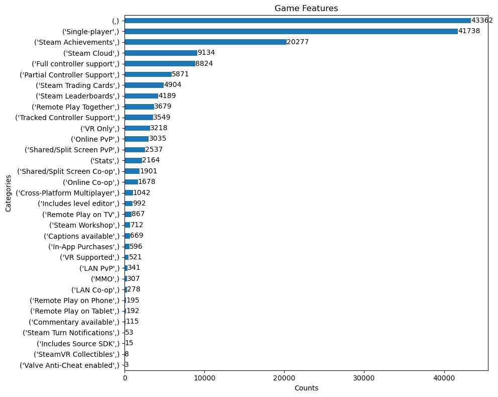

```python
# Plotting the horizontal bar chart
plt.figure(figsize=(10, 8))
ax = value_counts_gf.plot(kind='barh')  # Create the bar plot

plt.title('Game Features')
plt.xlabel('Counts')
plt.ylabel('Categories')
plt.gca().invert_yaxis()  # Invert y-axis to display the highest count at the top
plt.ticklabel_format(style='plain', axis='x')  # Disable scientific notation on x-axis

# Adding text annotations for values at the end of the bars
for i, v in enumerate(value_counts_gf):
    ax.text(v + 3, i, str(v), color='black', va='center')  # Adjust the "+3" offset for text placement

plt.tight_layout()
plt.show()
```

```python
# based on the value counts of "Game Features", we are going to keep all of the features that
# have a frequency higher than 4 and remove the empty values
value_counts_gf = value_counts_gf[value_counts_gf>4][1:]
value_counts_gf
```

```
'Single-player'                 41738
'Steam Achievements'            20277
'Steam Cloud'                    9134
'Full controller support'        8824
'Partial Controller Support'     5871
'Steam Trading Cards'            4904
'Steam Leaderboards'             4189
'Remote Play Together'           3679
'Tracked Controller Support'     3549
'VR Only'                        3218
'Online PvP'                     3035
'Shared/Split Screen PvP'        2537
'Stats'                          2164
'Shared/Split Screen Co-op'      1901
'Online Co-op'                   1678
'Cross-Platform Multiplayer'     1042
'Includes level editor'           992
'Remote Play on TV'               867
'Steam Workshop'                  712
'Captions available'              669
'In-App Purchases'                596
'VR Supported'                    521
'LAN PvP'                         341
'MMO'                             307
'LAN Co-op'                       278
'Remote Play on Phone'            195
'Remote Play on Tablet'           192
'Commentary available'            115
'Steam Turn Notifications'         53
'Includes Source SDK'              15
'SteamVR Collectibles'              8
dtype: int64
```

```python
value_counts_gf.shape
```

```
(31,)
```

```python
games_df.reset_index(drop=True,inplace=True)
```

```python
# Creating the dummy variables for game_features
game_features_list = [el[0].replace("'","") for el in value_counts_gf.index]
for feature in game_features_list:
    games_df[feature] = 0
for i in range(len(games_df)):
    for feature in game_features_list:
        if feature in games_df["Game Features"][i]:
            games_df.loc[i, feature] = 1
```

```python
games_df.head(2)
```

|  | Title | Original Price | Discounted Price | Release Date | Link | Game Description | Recent Reviews Summary | All Reviews Summary | Recent Reviews Number | All Reviews Number | ... | VR Supported | LAN PvP | MMO | LAN Co-op | Remote Play on Phone | Remote Play on Tablet | Commentary available | Steam Turn Notifications | Includes Source SDK | SteamVR Collectibles |
| --- | --- | --- | --- | --- | --- | --- | --- | --- | --- | --- | --- | --- | --- | --- | --- | --- | --- | --- | --- | --- | --- |
| 0 | Not Tonight 2 | $10.49 | $4.72 | 11 Feb, 2022 | https://store.steampowered.com/app/1600370/Not... | Immigration Enforcement Case #112: You are und... | Very Positive | NaN | - 86% of the 235 user reviews for this game ar... | NaN | ... | 0 | 0 | 0 | 0 | 0 | 0 | 0 | 0 | 0 | 0 |
| 1 | Forest Camp Story | $5.79 | $5.79 | 27 Nov, 2022 | https://store.steampowered.com/app/1983690/For... | Create and customize your own campground in th... | Very Positive | NaN | - 90% of the 85 user reviews for this game are... | NaN | ... | 0 | 0 | 0 | 0 | 0 | 0 | 0 | 0 | 0 | 0 |

2 rows × 52 columns

## PCA Transformation (Popular Tags)

Analysis and transformation of popular tags and summarization through Principal Component Analysis

```python
# Let's see how many tags are we dealing with
all_tags = " ".join(games_df["Popular Tags"].astype(str))
all_tags = all_tags.replace("[",",").replace("]",",")
all_tags_list = [el.strip() for el in all_tags.split(",")]

all_tags_pd = pd.DataFrame(all_tags_list)
value_counts = all_tags_pd.value_counts()
print(len(value_counts))
value_counts[value_counts>0]
```

```
441
```

```
                  43312
'Indie'           29096
'Singleplayer'    21521
'Casual'          20822
'Action'          19572
                  ...
'Shop Keeper'         4
'Fox'                 4
'TrackIR'             4
'Reboot'              3
'Birds'               1
Length: 441, dtype: int64
```

```python
# Convert the string representations of lists to actual lists
games_df['Popular Tags'] = games_df['Popular Tags'].apply(lambda x: ast.literal_eval(x))
```

```python
# Apply get_dummies directly on the 'Popular Tags' column
tags_dummies_df = games_df['Popular Tags'].str.join('|').str.get_dummies()
tags_dummies_df
```

|  | 1980s | 1990's | 2.5D | 2D | 2D Fighter | 2D Platformer | 360 Video | 3D | 3D Fighter | 3D Platformer | ... | Well-Written | Werewolves | Western | Wholesome | Word Game | World War I | World War II | Wrestling | Zombies | eSports |
| --- | --- | --- | --- | --- | --- | --- | --- | --- | --- | --- | --- | --- | --- | --- | --- | --- | --- | --- | --- | --- | --- |
| 0 | 0 | 0 | 0 | 1 | 0 | 0 | 0 | 0 | 0 | 0 | ... | 0 | 0 | 0 | 0 | 0 | 0 | 0 | 0 | 0 | 0 |
| 1 | 0 | 0 | 0 | 1 | 0 | 0 | 0 | 0 | 0 | 0 | ... | 0 | 0 | 0 | 0 | 0 | 0 | 0 | 0 | 0 | 0 |
| 2 | 0 | 1 | 1 | 1 | 0 | 1 | 0 | 0 | 0 | 0 | ... | 0 | 0 | 0 | 0 | 0 | 0 | 0 | 0 | 0 | 0 |
| 3 | 0 | 0 | 0 | 1 | 0 | 0 | 0 | 0 | 0 | 0 | ... | 0 | 0 | 0 | 0 | 0 | 0 | 0 | 0 | 0 | 0 |
| 4 | 0 | 0 | 0 | 0 | 0 | 0 | 0 | 0 | 0 | 0 | ... | 0 | 0 | 0 | 0 | 0 | 0 | 0 | 0 | 0 | 0 |
| ... | ... | ... | ... | ... | ... | ... | ... | ... | ... | ... | ... | ... | ... | ... | ... | ... | ... | ... | ... | ... | ... |
| 43298 | 0 | 0 | 0 | 1 | 0 | 1 | 0 | 0 | 0 | 0 | ... | 0 | 0 | 0 | 0 | 0 | 0 | 0 | 0 | 0 | 0 |
| 43299 | 0 | 0 | 0 | 0 | 0 | 0 | 0 | 0 | 0 | 0 | ... | 0 | 0 | 0 | 0 | 0 | 0 | 0 | 0 | 0 | 0 |
| 43300 | 0 | 0 | 0 | 0 | 0 | 0 | 0 | 0 | 0 | 0 | ... | 0 | 0 | 0 | 0 | 0 | 0 | 0 | 0 | 0 | 0 |
| 43301 | 0 | 0 | 0 | 0 | 0 | 0 | 0 | 1 | 0 | 1 | ... | 0 | 0 | 0 | 0 | 0 | 0 | 0 | 0 | 0 | 0 |
| 43302 | 0 | 0 | 0 | 0 | 0 | 0 | 0 | 1 | 0 | 0 | ... | 0 | 0 | 0 | 0 | 0 | 0 | 0 | 0 | 0 | 0 |

43303 rows × 440 columns

because there's too many features, we're going to use feature reudction PCA. source: https://mikulskibartosz.name/pca-how-to-choose-the-number-of-components

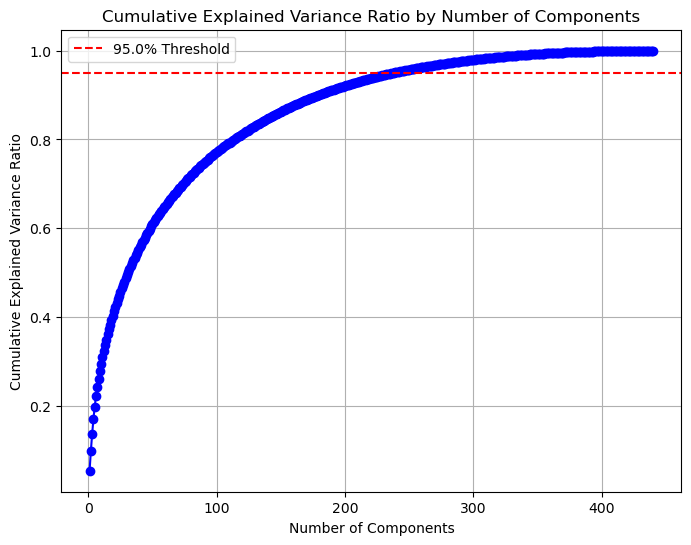

```
Number of components needed to achieve 95.0% threshold: 238
```

```python
import numpy as np
from sklearn.decomposition import PCA

pca = PCA()
pca.fit(tags_dummies_df)

# Calculate cumulative explained variance ratio
cumulative_var = np.cumsum(pca.explained_variance_ratio_)

# Plot the cumulative explained variance ratio
plt.figure(figsize=(8, 6))
plt.plot(range(1, len(cumulative_var) + 1), cumulative_var, marker='o', linestyle='-', color='b')
plt.xlabel('Number of Components')
plt.ylabel('Cumulative Explained Variance Ratio')
plt.title('Cumulative Explained Variance Ratio by Number of Components')
plt.grid(True)

threshold = 0.95  # Set the threshold here
plt.axhline(y=threshold, color='r', linestyle='--', label=f'{threshold*100}% Threshold')
plt.legend()


plt.show()

# Find the number of components that achieve the desired threshold
num_components = np.argmax(cumulative_var >= threshold) + 1

print(f"Number of components needed to achieve {threshold*100}% threshold: {num_components}")
```

```python
# Since there is way too many variables and we would like for the user to be able to input as many as they want
# We'll apply Principal Component Analysis (PCA) to summarize the tags so that the predictive model can handle them
# more efficiently
from sklearn.decomposition import PCA

pca = PCA(n_components=num_components)  # Specify the desired number of components based on the previous plot
pca.fit(tags_dummies_df)
# Transform the data using PCA
df_pca = pd.DataFrame(pca.transform(tags_dummies_df), columns=[f'PCA_{i}' for i in range(pca.n_components_)])

df_pca.head()
```

|  | PCA_0 | PCA_1 | PCA_2 | PCA_3 | PCA_4 | PCA_5 | PCA_6 | PCA_7 | PCA_8 | PCA_9 | ... | PCA_228 | PCA_229 | PCA_230 | PCA_231 | PCA_232 | PCA_233 | PCA_234 | PCA_235 | PCA_236 | PCA_237 |
| --- | --- | --- | --- | --- | --- | --- | --- | --- | --- | --- | --- | --- | --- | --- | --- | --- | --- | --- | --- | --- | --- |
| 0 | 0.409657 | -0.324480 | 0.591374 | -0.847256 | 0.609709 | 0.003414 | -0.087016 | 0.017850 | 0.658866 | -0.022729 | ... | 0.117069 | -0.097110 | -0.206132 | 0.277560 | 0.127647 | 0.162974 | -0.130298 | 0.278489 | 0.072791 | 0.065839 |
| 1 | 0.694280 | -0.731256 | -0.804323 | -0.131967 | 0.679628 | -0.766924 | 0.381220 | 0.242563 | 0.913800 | -0.630273 | ... | 0.043569 | -0.015040 | -0.044558 | 0.030819 | -0.001442 | 0.061336 | -0.061068 | 0.025783 | 0.030147 | -0.007183 |
| 2 | 0.803688 | -0.764302 | -0.712482 | -0.142711 | 0.702741 | -0.562767 | 0.513145 | 0.434236 | 1.110108 | -0.440919 | ... | 0.050786 | -0.036438 | -0.089431 | -0.067511 | 0.011603 | -0.057506 | -0.060196 | 0.002193 | -0.014653 | 0.018034 |
| 3 | 0.929491 | -0.932884 | -0.726056 | -0.114928 | 0.522740 | -0.842807 | 0.088108 | -0.060701 | 0.774992 | -0.580296 | ... | 0.125382 | 0.052405 | -0.023821 | 0.057092 | 0.020841 | 0.081334 | -0.024063 | 0.068355 | -0.003734 | -0.024518 |
| 4 | -0.270744 | 0.983164 | 0.345343 | 0.082186 | -0.110755 | -0.321691 | 0.829532 | -0.277355 | 0.007374 | 0.067947 | ... | 0.462584 | -0.067987 | -0.153376 | 0.059805 | -0.254568 | 0.153198 | -0.199089 | 0.094935 | -0.468095 | -0.160779 |

5 rows × 238 columns

```python
# Save the PCA components to use on the website
np.savetxt('pca_components.csv', pca.components_, delimiter=',')
```

```python
# Concatenate the PCA features into the games_df dataframe
games_df = pd.concat([games_df, df_pca], axis=1)
games_df.head(1)
```

|  | Title | Original Price | Discounted Price | Release Date | Link | Game Description | Recent Reviews Summary | All Reviews Summary | Recent Reviews Number | All Reviews Number | ... | PCA_228 | PCA_229 | PCA_230 | PCA_231 | PCA_232 | PCA_233 | PCA_234 | PCA_235 | PCA_236 | PCA_237 |
| --- | --- | --- | --- | --- | --- | --- | --- | --- | --- | --- | --- | --- | --- | --- | --- | --- | --- | --- | --- | --- | --- |
| 0 | Not Tonight 2 | $10.49 | $4.72 | 11 Feb, 2022 | https://store.steampowered.com/app/1600370/Not... | Immigration Enforcement Case #112: You are und... | Very Positive | NaN | - 86% of the 235 user reviews for this game ar... | NaN | ... | 0.117069 | -0.09711 | -0.206132 | 0.27756 | 0.127647 | 0.162974 | -0.130298 | 0.278489 | 0.072791 | 0.065839 |

1 rows × 290 columns